# 20250509_Análisis variabilidad de tasas

```python
# Limpiar todas las variables del espacio de trabajo
%reset -f
```

```python
import pandas as pd
import seaborn as sns
import matplotlib.pyplot as plt
```

```python
# Import data
data_df = pd.read_stata(r"C:\Users\ylondono\Proantioquia\Proantioquia Team Site - ACV\PRODUCTOS\EJERCICIO CLUSTERIZACIÓN MUNICIPAL ANTIOQUIA\DATOS\BASES HOMOGENEIZADAS\Final_Data\20250610_DATA.dta")
display(data_df.head())
```

|  | ind_mpio | nvl_label | percepción_seguridad | tasa_delitos | IRV | VBG | homicidios | vinculacion_nna | BVG_jovenes | EDA | ... | TS_30_59 | TS_15_64 | TS_hombres | TS_mujeres | TIS_total | TIS_15_29 | TIS_30_59 | TIS_15_64 | TIS_hombres | TIS_mujeres |
| --- | --- | --- | --- | --- | --- | --- | --- | --- | --- | --- | --- | --- | --- | --- | --- | --- | --- | --- | --- | --- | --- |
| 0 | 05001 | Medellín | .6068024718288 | .0677347394037721 | .18356099 | 384.6568797441529 | 11.3517573246545 | 0 | 596.7623059466483 | 0 | ... | 11.1064134404402 | 11.9006597833972 | 15.9544047657034 | 3.7143125572168 | 110.08361 | 267.3085 | 74.384972 | 129.55491 | 79.199299 | 137.57522 |
| 1 | 05002 | Abejorral | .8271909756534499 | .0129032258064516 | .19629357 | 910.9264215617222 | 46.5809577044904 | 0 | 1692.841117683051 | 0 | ... | NA | 7.13877784123358 | NA | 9.84251968503937 | 291.12083 | 710.73204 | 214.36228 | 328.38377 | 215.4979 | 374.01575 |
| 2 | 05004 | Abriaquí | .9504767291532 | 0 | .0996653 | 175.9943681802182 | 0 | 0 | 571.4285714285714 | 0 | ... | NA | NA | NA | NA | NA | NA | NA | NA | NA | NA |
| 3 | 05021 | Alejandría | .8874424773485931 | .0086580086580087 | .10863511 | 81.43322475570032 | 20.1816347124117 | 0 | 90.49773755656109 | 0 | ... | 53.8793103448276 | 32.258064516129 | 40.9165302782324 | NA | 61.07492 | 102.77493 | NA | 32.258064 | NA | 121.55592 |
| 4 | 05030 | Amagá | .860060582707564 | .0064205457463884 | .12925666 | 267.5626905606372 | 37.0233246945576 | 0 | 293.2909690822436 | 0 | ... | 7.51766651631334 | 22.2074172773706 | 12.6911606066375 | 18.3116645303058 | 6.2223882 | 26.907036 | NA | 8.8829668 | NA | 12.207776 |

5 rows × 222 columns

```python
# Exportar data en excel para ver mejor
#output_path = r"C:\Users\ylondono\Proantioquia\Proantioquia Team Site - ACV\PRODUCTOS\EJERCICIO CLUSTERIZACIÓN MUNICIPAL ANTIOQUIA\DATOS\BASES HOMOGENEIZADAS\Final_Data\20250610_DATA.xlsx"
#data_df.to_excel(output_path, index=False)
#print(f"Archivo exportado correctamente a:\n{output_path}")
```

```python
# Importar diccionario
diccionario_df = pd.read_excel(
    r"C:\Users\ylondono\Proantioquia\Proantioquia Team Site - ACV\PRODUCTOS\EJERCICIO CLUSTERIZACIÓN MUNICIPAL ANTIOQUIA\DATOS\BASES HOMOGENEIZADAS\Final_Data\20250610_DICCIONARIO.XLSX"
)
display(diccionario_df)
```

|  | var_id | variable | var_periodos | Unidad de medida | Unidad de medida_descriptiva | Tipo | Subdimensión | id_nivel | Fuente | Responsable homogeneización | Ajuste necesario por varianza |
| --- | --- | --- | --- | --- | --- | --- | --- | --- | --- | --- | --- |
| 0 | percepción_seguridad | Porcentaje de jefes(a) de hogar o informantes ... | 2023 | Porcentaje | 0 | Contexto | Seguridad | 0 | Encuesta de Calidad de Vida - Gobernación de A... | Yeison | 0 |
| 1 | tasa_delitos | Tasa de delitos | 2023 | Tasa | 0 | Contexto | Seguridad | 0 | Encuesta de Calidad de Vida - Gobernación de A... | Yeison | 0 |
| 2 | IRV | Índice de Riesgo de Victimización | 2023 | Índice | 0 | Contexto | Seguridad | 0 | UARIV | Yeison | 0 |
| 3 | VBG | Incidencia de VCM VIF VSX por cada 100.000 ha... | 2023 | Tasa | 0 | Contexto | Seguridad | 0 | SIVIGILA | Yeison | 0 |
| 4 | homicidios | Tasa de homicidios por cada 100 mil habitantes | 2024 | Tasa | 0 | Contexto | Seguridad | 0 | SIEDCO | Yeison | 0 |
| ... | ... | ... | ... | ... | ... | ... | ... | ... | ... | ... | ... |
| 214 | va_primario | Participacion por actidad economica del Valor ... | 2023 | Porcentaje | Porcentaje | 0 | Desarrollo económico | 0 | Gobernación de Antioquía | Miguel | 0 |
| 215 | VPC_pri | Kilómetros de vías primarias por cada 1000 hab... | 0 | Tasa | cada 1000 habitantes | 0 | Desarrollo económico | 0 | RV CIRCULAR 10 - Gobernación de Antioquia | Miguel | 0 |
| 216 | VPC_sec | Kilómetros de vías secundarias por cada 1000 h... | 0 | Tasa | cada 1000 habitantes | 0 | Desarrollo económico | 0 | RV CIRCULAR 10 - Gobernación de Antioquia | Miguel | 0 |
| 217 | VPC_ter | Kilómetros de vías terciarias por cada 1000 ha... | 0 | Tasa | cada 1000 habitantes | 0 | Desarrollo económico | 0 | RV CIRCULAR 10 - Gobernación de Antioquia | Miguel | 0 |
| 218 | VPC_total | Kilómetros de vías en total por cada 1000 habi... | 0 | Tasa | cada 1000 habitantes | 0 | Desarrollo económico | 0 | RV CIRCULAR 10 - Gobernación de Antioquia | Miguel | 0 |

219 rows × 11 columns

```python
list(data_df.columns)
```

```
['ind_mpio',
 'nvl_label',
 'percepción_seguridad',
 'tasa_delitos',
 'IRV',
 'VBG',
 'homicidios',
 'vinculacion_nna',
 'BVG_jovenes',
 'EDA',
 'mortalidad_desnutrición',
 'bajo_peso',
 'desnutrición_aguda',
 'controles_prenatales',
 'fecundidad_niñas',
 'fecundidad_adolescentes',
 'camas',
 'IRA',
 'dengue',
 'malaria',
 'leishmaniasis',
 'agua_rural',
 'alcantarillado_rural',
 'agua_urbano',
 'alcantarillado_urbano',
 'deficit_cuali',
 'deficit_cuanti',
 'hacinamiento_rural',
 'hacinamiento_urbano',
 'Población_2023',
 'IRCC',
 'afectados_dn',
 'perdida_ca',
 'VBG_jovenes',
 'dens_emp',
 'fin_banc_pc',
 'fin_microcr_pc',
 'internet',
 'ss_pension_hombres',
 'ss_pension_mujeres',
```

[output cut: 167 more lines]

```
 'PU_j_M_12_28',
 'PU_ad_M_29_59',
 'PU_v_M_60_85',
 'TS_total',
 'TS_15_29',
 'TS_30_59',
 'TS_15_64',
 'TS_hombres',
 'TS_mujeres',
 'TIS_total',
 'TIS_15_29',
 'TIS_30_59',
 'TIS_15_64',
 'TIS_hombres',
 'TIS_mujeres']
```

```python
# Ajustes temporales en los datos
# VBG
#delete VBG_jovenes
data_df.drop(columns=["VBG_jovenes"], inplace=True)
#rename BVG_jovenes por VBG_jovenes
data_df.rename(columns={"BVG_jovenes": "VBG_jovenes"}, inplace=True)

# rename "I_enve_c_T” por “I_enve_T_c"
data_df.rename(columns={"I_enve_c_T": "I_enve_T_c"}, inplace=True)
```

```python
# 2. Verificar que todas las columnas de la base estén definidas en el diccionario

# Conjuntos de nombres
dicc_vars = set(diccionario_df["var_id"].tolist())
data_vars = set(data_df.columns.tolist())

# Variables en data_df que NO están en el diccionario
vars_sin_dicc = data_vars - dicc_vars
print("Columnas en data_df que NO están en el diccionario:")
print(sorted(vars_sin_dicc), "\n")

# Variables en el diccionario que NO aparecen en data_df
vars_sin_data = dicc_vars - data_vars
print("Indicadores en el diccionario que NO aparecen en data_df:")
print(sorted(vars_sin_data))
```

```
Columnas en data_df que NO están en el diccionario:
['ind_mpio', 'nvl_label']

Indicadores en el diccionario que NO aparecen en data_df:
[]
```

```python
# 4. Identificar indicadores tipo 'Tasa'
tasa_vars = (
    diccionario_df
    .loc[diccionario_df["Unidad de medida"].str.lower() == "tasa", "var_id"]
    .tolist()
)
# Mantener sólo los que efectivamente existen
tasa_vars = [v for v in tasa_vars if v in data_df.columns]
print("Indicadores de tipo tasa reales:", tasa_vars)

# 5. Construir subset con municipio, población y tasas
tasa_data = data_df[["ind_mpio", "nvl_label", "Población_2023"] + tasa_vars].copy()
tasa_data[tasa_vars] = tasa_data[tasa_vars].apply(pd.to_numeric, errors='coerce').astype(float)
# Formato de 2 decimales
pd.options.display.float_format = "{:.2f}".format
```

[output not shown]

```python
print("Subset con municipio, población y tasas:")
display(tasa_data.head())
```

```
Subset con municipio, población y tasas:
```

|  | ind_mpio | nvl_label | Población_2023 | tasa_delitos | VBG | homicidios | vinculacion_nna | VBG_jovenes | EDA | mortalidad_desnutrición | ... | TS_15_64 | TS_30_59 | TS_hombres | TS_mujeres | TS_total | va_pc | VPC_pri | VPC_sec | VPC_ter | VPC_total |
| --- | --- | --- | --- | --- | --- | --- | --- | --- | --- | --- | --- | --- | --- | --- | --- | --- | --- | --- | --- | --- | --- |
| 0 | 05001 | Medellín | 2595300 | 0.07 | 384.66 | 11.35 | 0.00 | 596.76 | 0.00 | 2.90 | ... | 11.90 | 11.11 | 15.95 | 3.71 | 9.48 | 21625.33 | 0.05 | 0.01 | 0.00 | 0.06 |
| 1 | 05002 | Abejorral | 21297 | 0.01 | 910.93 | 46.58 | 0.00 | 1692.84 | 0.00 | 0.00 | ... | 7.14 | NaN | NaN | 9.84 | 4.70 | 12376.67 | 0.43 | 4.80 | 8.52 | 13.75 |
| 2 | 05004 | Abriaquí | 2841 | 0.00 | 175.99 | 0.00 | 0.00 | 571.43 | 0.00 | 0.00 | ... | NaN | NaN | NaN | NaN | NaN | 11781.74 | 0.00 | 8.68 | 19.47 | 28.15 |
| 3 | 05021 | Alejandría | 4912 | 0.01 | 81.43 | 20.18 | 0.00 | 90.50 | 0.00 | 0.00 | ... | 32.26 | 53.88 | 40.92 | NaN | 20.36 | 9707.52 | 0.00 | 3.88 | 9.83 | 13.71 |
| 4 | 05030 | Amagá | 32142 | 0.01 | 267.56 | 37.02 | 0.00 | 293.29 | 0.00 | 0.00 | ... | 22.21 | 7.52 | 12.69 | 18.31 | 15.56 | 17003.95 | 0.71 | 0.41 | 2.47 | 3.59 |

5 rows × 43 columns

```python
#Verificar que todas las variables del subset tasa_data sean númericas (excepto por ind_mpio y nvl_label)
# Seleccionar todas las columnas excepto las no numéricas deseadas
cols_a_verificar = [col for col in tasa_data.columns if col not in ["ind_mpio", "nvl_label"]]

# Verificar tipos de datos
tipos = tasa_data[cols_a_verificar].dtypes

# Filtrar columnas que NO son numéricas
no_numericas = tipos[~tipos.apply(pd.api.types.is_numeric_dtype)]

# Mostrar resultado
print("Columnas no numéricas en el subset:")
print(no_numericas)

# Convierte todas a númericas
# Identificar columnas que no son numéricas
no_numericas = tipos[~tipos.apply(pd.api.types.is_numeric_dtype)].index.tolist()
# Convertirlas a numéricas (coercion convierte errores a NaN)
tasa_data[no_numericas] = tasa_data[no_numericas].apply(pd.to_numeric, errors="coerce")
```

```
Columnas no numéricas en el subset:
Población_2023    object
dtype: object
```

```python
# 7. Definir grupos de tamaño basados en cuantiles de población
q1, q2 = tasa_data['Población_2023'].quantile([0.33, 0.66])
print(f"Umbrales de población (terciles): Pequeño < {q1:.0f}, Mediano < {q2:.0f}, Grande ≥ {q2:.0f}")

def clasificar_tamano(p):
    if p < q1:
        return "Pequeño"
    elif p < q2:
        return "Mediano"
    else:
        return "Grande"

tasa_data["Grupo_tamano"] = tasa_data["Población_2023"].apply(clasificar_tamano)
print("Conteo por Grupo_tamano:")
print(tasa_data["Grupo_tamano"].value_counts())
```

```
Umbrales de población (terciles): Pequeño < 10721, Mediano < 25953, Grande ≥ 25953
Conteo por Grupo_tamano:
Grupo_tamano
Grande     43
Mediano    41
Pequeño    41
Name: count, dtype: int64
```

```python
# 7. Agrupar municipios por población usando K-Means (3 clusters)
from sklearn.cluster import KMeans
# Preparar datos de población
demographics = tasa_data["Población_2023"].values.reshape(-1, 1)
# Ajustar modelo K-Means con 3 clusters
kmeans = KMeans(n_clusters=3, random_state=42).fit(demographics)
labels = kmeans.labels_
# Obtener centroides y mapear a categorías
centroids = kmeans.cluster_centers_.flatten()
order = centroids.argsort()
label_map = {order[0]: "Pequeño", order[1]: "Mediano", order[2]: "Grande"}
# Asignar categoría según label
tasa_data["Grupo_tamano"] = [label_map[label] for label in labels]
print("Centroides de población:", centroids)
print("Conteo por Grupo_tamano:")
print(tasa_data["Grupo_tamano"].value_counts())
```

```
Centroides de población: [ 368411.66666667   26015.08264463 2595300.        ]
Conteo por Grupo_tamano:
Grupo_tamano
Pequeño    121
Mediano      3
Grande       1
Name: count, dtype: int64
```

```python
import os
os.environ["OMP_NUM_THREADS"] = "1"
```

```python
# 7. Agrupar municipios por población usando K-Means sobre log(Población)
import numpy as np
from sklearn.cluster import KMeans
# Tomar logaritmo de la población para mitigar outliers
tasa_data['log_pob'] = np.log1p(tasa_data['Población_2023'])
# Preparar datos para clustering
demographics_log = tasa_data['log_pob'].values.reshape(-1,1)
# Ajustar modelo K-Means con 3 clusters
kmeans = KMeans(n_clusters=3, random_state=42).fit(demographics_log)
labels = kmeans.labels_
# Calcular centroides en escala original
centroids_log = kmeans.cluster_centers_.flatten()
centroids_orig = np.expm1(centroids_log)
# Ordenar clusters por población promedio
order = np.argsort(centroids_log)
label_map = {order[0]: 'Pequeño', order[1]: 'Mediano', order[2]: 'Grande'}
# Asignar etiqueta de grupo según cluster
tasa_data['Grupo_tamano'] = [label_map[l] for l in labels]
print('Centroides (log-scale):', centroids_log)
print('Centroides (población):', centroids_orig.astype(int))
print('Conteo por Grupo_tamano:')
print(tasa_data['Grupo_tamano'].value_counts())
# Eliminar columna temporal
del tasa_data['log_pob']
```

```
Centroides (log-scale): [11.67377994 10.09541272  8.92495079]
Centroides (población): [117450  24230   7516]
Conteo por Grupo_tamano:
Grupo_tamano
Mediano    55
Pequeño    50
Grande     20
Name: count, dtype: int64
```

### Análisis de volatilidad del subset de indicadores tipo tasa

Luego de haber definido el subconjunto de variables tipo tasa, se desarrolló un proceso metodológico orientado a evaluar **la estabilidad y validez de estas tasas según el tamaño poblacional municipal**. El objetivo fue identificar si las tasas observadas en municipios pequeños son confiables o si podrían estar distorsionadas por el bajo denominador. Los pasos seguidos fueron los siguientes:

### 1. Cálculo de estadísticas descriptivas por grupo de tamaño poblacional

```python
# Agrupar por grupo de tamaño y calcular medias y medianas de cada tasa
mean_by_group = tasa_data.groupby("Grupo_tamano")[tasa_vars].mean().add_suffix("_mean")
median_by_group = tasa_data.groupby("Grupo_tamano")[tasa_vars].median().add_suffix("_median")

# Unir ambas tablas
resumen_tendencia = pd.concat([mean_by_group, median_by_group], axis=1)

# Mostrar la tabla
print("Resumen de medias y medianas por grupo de tamaño poblacional:")
display(resumen_tendencia)
```

```
Resumen de medias y medianas por grupo de tamaño poblacional:
```

| Grupo_tamano | tasa_delitos_mean | VBG_mean | homicidios_mean | vinculacion_nna_mean | VBG_jovenes_mean | EDA_mean | mortalidad_desnutrición_mean | desnutrición_aguda_mean | fecundidad_niñas_mean | fecundidad_adolescentes_mean | ... | TS_15_64_median | TS_30_59_median | TS_hombres_median | TS_mujeres_median | TS_total_median | va_pc_median | VPC_pri_median | VPC_sec_median | VPC_ter_median | VPC_total_median |
| --- | --- | --- | --- | --- | --- | --- | --- | --- | --- | --- | --- | --- | --- | --- | --- | --- | --- | --- | --- | --- | --- |
| Grande | 0.03 | 317.95 | 22.00 | 0.46 | 481.88 | 0.91 | 2.24 | 410.89 | 2.06 | 35.97 | ... | 12.25 | 10.32 | 15.49 | 3.09 | 9.34 | 17734.27 | 0.27 | 0.07 | 1.46 | 1.83 |
| Mediano | 0.02 | 258.44 | 50.74 | 3.22 | 409.82 | 1.63 | 2.68 | 433.75 | 3.16 | 56.73 | ... | 11.75 | 12.61 | 14.47 | 8.91 | 8.89 | 12376.67 | 0.93 | 1.95 | 6.37 | 9.33 |
| Pequeño | 0.02 | 260.44 | 49.33 | 2.68 | 453.56 | 2.24 | 4.53 | 411.52 | 1.75 | 34.96 | ... | 23.05 | 35.49 | 25.99 | 25.75 | 13.87 | 11149.07 | 0.00 | 2.99 | 8.66 | 14.31 |

3 rows × 80 columns

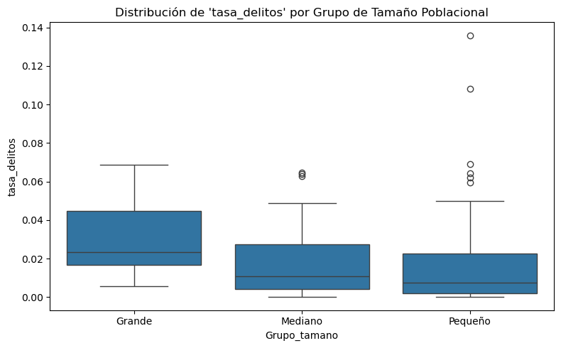

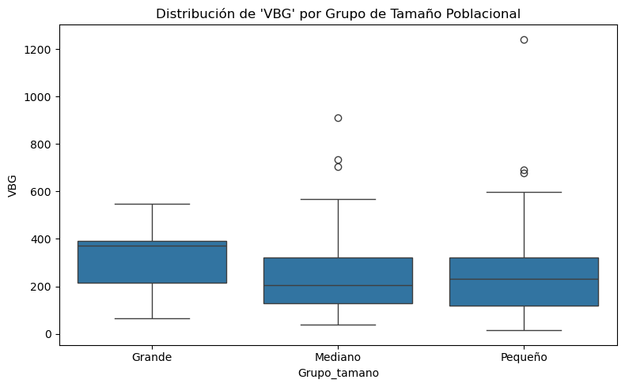

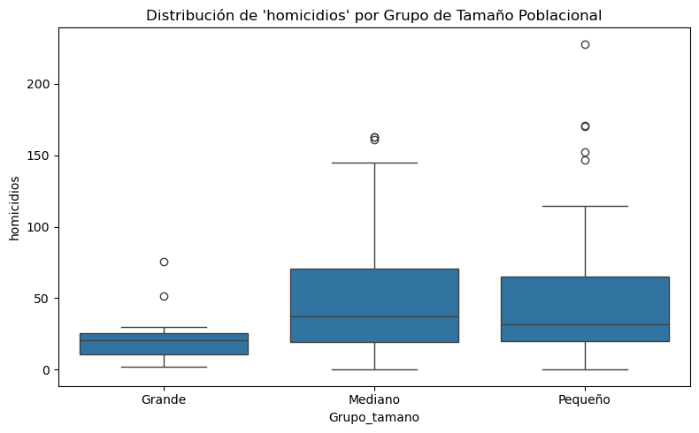

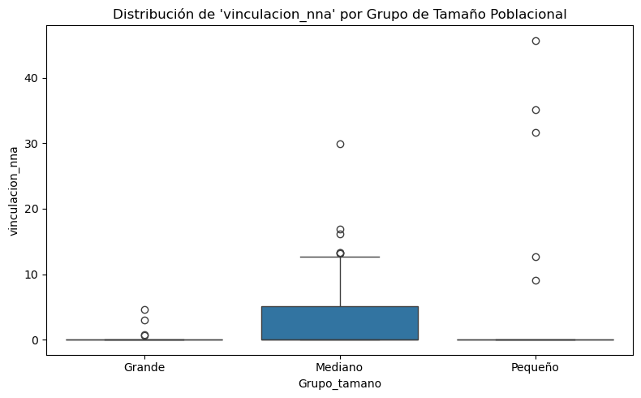

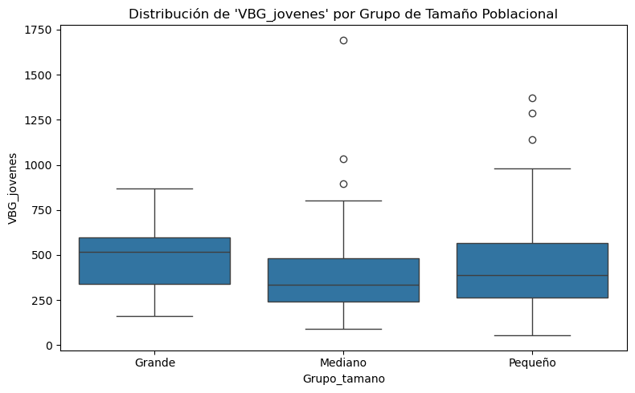

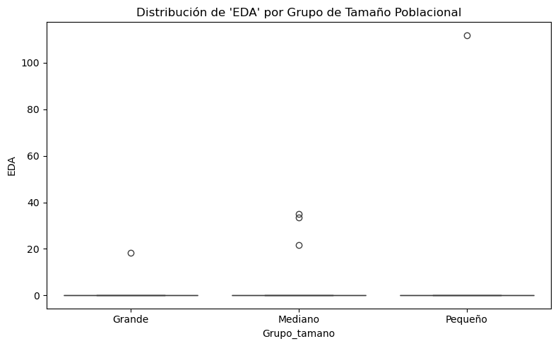

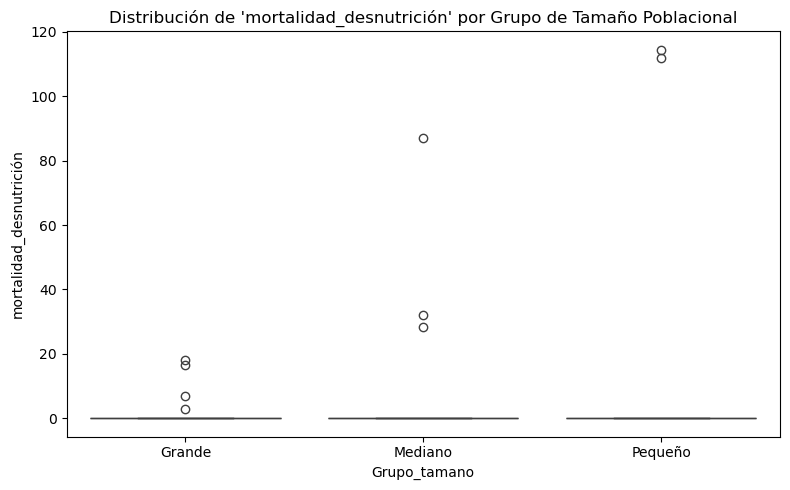

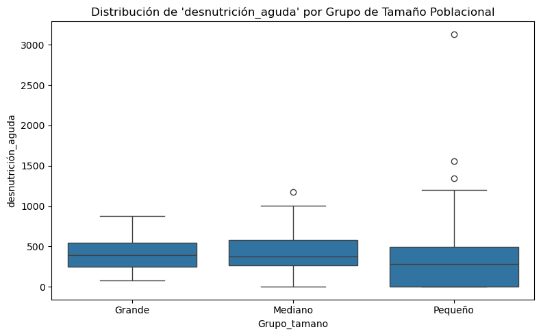

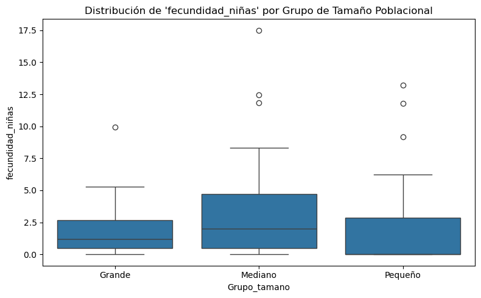

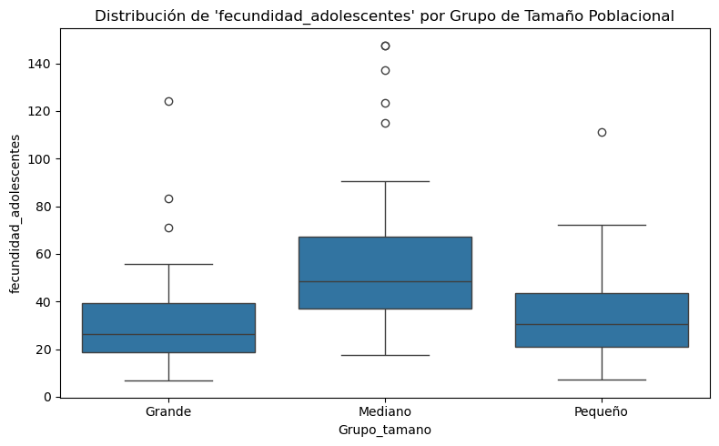

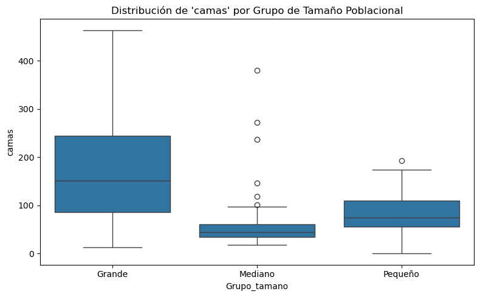

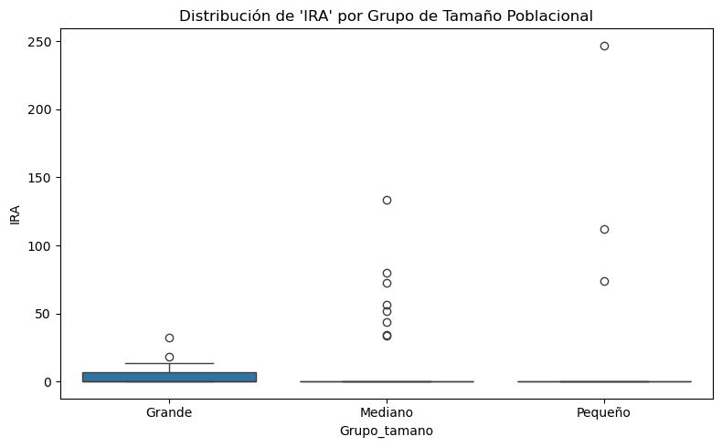

[28 more figures not shown]

```python
# Mostrar boxplots para cada tasa
for var in tasa_vars:
    plt.figure(figsize=(8, 5))
    sns.boxplot(x="Grupo_tamano", y=var, data=tasa_data)
    plt.title(f"Distribución de '{var}' por Grupo de Tamaño Poblacional")
    plt.ylabel(var)
    plt.xlabel("Grupo_tamano")
    plt.tight_layout()
    plt.show()
```

**Análisis de varianza por tamaño poblacional con prueba de Kruskal-Wallis**

Para identificar si las tasas de ciertos indicadores varían significativamente según el tamaño poblacional de los municipios, se aplicó la **prueba de Kruskal-Wallis**, una prueba no paramétrica que compara la distribución de una variable continua entre tres o más grupos independientes. A diferencia del ANOVA, esta prueba no asume normalidad y es adecuada para datos con asimetrías o varianzas desiguales, como es común en tasas municipales.

Interpretación del valor p: Un valor p bajo (< 0.05) indica que al menos uno de los grupos (Pequeño, Mediano o Grande) presenta una distribución diferente en ese indicador. En nuestro caso, nos interesa especialmente cuando el grupo "Pequeño" registra sistemáticamente valores más altos que los demás, ya que esto puede sugerir que la tasa está siendo amplificada artificialmente por el bajo tamaño poblacional, afectando la estabilidad e interpretación del indicador.

```python
#Pruebas estadísticas (ANOVA y Kruskal-Wallis)
from scipy.stats import f_oneway, kruskal

# Inicializar resultados
resultados_test = []

for var in tasa_vars:
    grupos = [
        tasa_data[tasa_data["Grupo_tamano"] == g][var].dropna()
        for g in ["Pequeño", "Mediano", "Grande"]
    ]

    # ANOVA: supuestos paramétricos
    try:
        f_stat, p_anova = f_oneway(*grupos)
    except:
        p_anova = None

    # Kruskal-Wallis: no paramétrico
    try:
        h_stat, p_kw = kruskal(*grupos)
    except:
        p_kw = None

    resultados_test.append({
        "Variable": var,
        "p_ANOVA": p_anova,
        "p_Kruskal_Wallis": p_kw
    })

# Convertir a DataFrame
resultados_df = pd.DataFrame(resultados_test)

# Mostrar tabla ordenada por significancia
resultados_df.sort_values("p_Kruskal_Wallis", inplace=True)
print("Resultados de pruebas estadísticas por variable:")
display(resultados_df)
```

```
Resultados de pruebas estadísticas por variable:
```

|  | Variable | p_ANOVA | p_Kruskal_Wallis |
| --- | --- | --- | --- |
| 39 | VPC_total | 0.00 | 0.00 |
| 38 | VPC_ter | 0.00 | 0.00 |
| 37 | VPC_sec | 0.00 | 0.00 |
| 10 | camas | 0.00 | 0.00 |
| 19 | IDV_pri | 0.00 | 0.00 |
| 29 | TS_15_29 | 0.00 | 0.00 |
| 9 | fecundidad_adolescentes | 0.00 | 0.00 |
| 33 | TS_mujeres | 0.00 | 0.00 |
| 35 | va_pc | 0.04 | 0.00 |
| 30 | TS_15_64 | 0.00 | 0.00 |
| 31 | TS_30_59 | 0.00 | 0.00 |
| 13 | malaria | 0.63 | 0.00 |
| 16 | dens_emp | 0.03 | 0.00 |
| 32 | TS_hombres | 0.00 | 0.00 |
| 17 | fin_banc_pc | 0.00 | 0.00 |
| 0 | tasa_delitos | 0.05 | 0.00 |
| 14 | leishmaniasis | 0.00 | 0.00 |
| 20 | IDV_sec | 0.00 | 0.00 |
| 34 | TS_total | 0.00 | 0.00 |
| 24 | TIS_15_64 | 0.09 | 0.00 |
| 28 | TIS_total | 0.15 | 0.00 |
| 8 | fecundidad_niñas | 0.07 | 0.01 |
| 27 | TIS_mujeres | 0.10 | 0.01 |
| 2 | homicidios | 0.03 | 0.01 |
| 23 | TIS_15_29 | 0.14 | 0.01 |
| 25 | TIS_30_59 | 0.02 | 0.01 |
| 36 | VPC_pri | 0.15 | 0.01 |
| 26 | TIS_hombres | 0.16 | 0.02 |
| 11 | IRA | 0.85 | 0.03 |
| 1 | VBG | 0.45 | 0.06 |
| 3 | vinculacion_nna | 0.33 | 0.07 |
| 6 | mortalidad_desnutrición | 0.81 | 0.08 |
| 12 | dengue | 0.60 | 0.09 |
| 7 | desnutrición_aguda | 0.95 | 0.10 |
| 21 | IDV_ter | 0.68 | 0.12 |
| 15 | afectados_dn | 0.40 | 0.13 |
| 4 | VBG_jovenes | 0.54 | 0.14 |
| 22 | IDV_total | 0.13 | 0.25 |
| 5 | EDA | 0.90 | 0.66 |
| 18 | fin_microcr_pc | 0.84 | 0.98 |

✅ **Cómo interpretar los valores p**

- **Si p < 0.05:** Hay evidencia estadística de que la tasa es significativamente diferente en al menos uno de los grupos de tamaño. Un P bajo sugiere que municipios Pequeños, Medianos y Grandes tienen valores distintos, y esa diferencia podría deberse al efecto del denominador (población) o a condiciones estructurales.
- **Si p ≥ 0.05:** No hay evidencia suficiente para decir que la tasa varía significativamente entre grupos. Un p alto sugiere que la variabilidad de esa tasa no está asociada al tamaño poblacional — es decir, los municipios pequeños no necesariamente muestran valores más extremos que los grandes.

Usa Kruskal-Wallis como referencia principal si tus datos no siguen una distribución normal (lo más probable en datos municipales).

```python
# Filtrar la tabla resultados_df y mostrar únicamente los resultados de la prueba Kruskal-Wallis con p < 0.05
# (evidencia estadística de diferencia significativa entre grupos poblacionales):

# Filtrar resultados con p < 0.05 en la prueba de Kruskal-Wallis
resultados_significativos = resultados_df[resultados_df["p_Kruskal_Wallis"] < 0.05][["Variable", "p_Kruskal_Wallis"]]

# Contar cuántos indicadores tienen p < 0.05 y calcular el porcentaje
n_significativos = resultados_significativos.shape[0]
n_total = resultados_df.shape[0]
porcentaje = (n_significativos / n_total) * 100

# Mostrar resumen y tabla ordenada
print(f"{n_significativos} de {n_total} indicadores ({porcentaje:.1f}%) presentan diferencias significativas entre grupos poblacionales (p < 0.05, Kruskal-Wallis).")
display(resultados_significativos.sort_values(by="Variable"))
```

```
29 de 40 indicadores (72.5%) presentan diferencias significativas entre grupos poblacionales (p < 0.05, Kruskal-Wallis).
```

|  | Variable | p_Kruskal_Wallis |
| --- | --- | --- |
| 19 | IDV_pri | 0.00 |
| 20 | IDV_sec | 0.00 |
| 11 | IRA | 0.03 |
| 23 | TIS_15_29 | 0.01 |
| 24 | TIS_15_64 | 0.00 |
| 25 | TIS_30_59 | 0.01 |
| 26 | TIS_hombres | 0.02 |
| 27 | TIS_mujeres | 0.01 |
| 28 | TIS_total | 0.00 |
| 29 | TS_15_29 | 0.00 |
| 30 | TS_15_64 | 0.00 |
| 31 | TS_30_59 | 0.00 |
| 32 | TS_hombres | 0.00 |
| 33 | TS_mujeres | 0.00 |
| 34 | TS_total | 0.00 |
| 36 | VPC_pri | 0.01 |
| 37 | VPC_sec | 0.00 |
| 38 | VPC_ter | 0.00 |
| 39 | VPC_total | 0.00 |
| 10 | camas | 0.00 |
| 16 | dens_emp | 0.00 |
| 9 | fecundidad_adolescentes | 0.00 |
| 8 | fecundidad_niñas | 0.01 |
| 17 | fin_banc_pc | 0.00 |
| 2 | homicidios | 0.01 |
| 14 | leishmaniasis | 0.00 |
| 13 | malaria | 0.00 |
| 0 | tasa_delitos | 0.00 |
| 35 | va_pc | 0.00 |

### 2. Evaluación de patrones de magnitud

Se compararon las medianas y p95 entre grupos para identificar si los municipios pequeños tienden a tener tasas más altas. Se generó una tabla de diagnóstico categorizando los indicadores según este patrón.

Inicialmente se hizo este ejercicio para los indicadores con diferencias significativas entre grupos poblacionales según la prueba de Kruskal-Wallis buscanndo determinar si los **municipios pequeños tienden a registrar tasas más altas**, no obstante finalmente se decidió enfocar el análisis de estabilidad únicamente en aquellos **indicadores que mostraban tasas más altas en municipios pequeños**, independientemente del valor p del test. Esto se justificó por el objetivo principal del estudio: **identificar potenciales distorsiones inducidas por el bajo denominador poblacional**, más que diferencias estadísticas globales entre grupos. La información del test fue útil como insumo adicional, pero no constituyó el criterio principal de priorización para el análisis cualitativo.

Para ello:

1. Se calculan estadísticas descriptivas (media, desviación estándar, percentiles 5, 50 y 95) por grupo de tamaño poblacional.
2. Se seleccionan únicamente los indicadores que presentaron diferencias estadísticamente significativas entre grupos de tamaño poblacional según la prueba de Kruskal-Wallis. **Luego se hace el ejericicio sin este filtro**
3. Se comparan las medianas (q50) y los percentiles 95 (q95) de estos indicadores para cada grupo.
4. Si el grupo “Pequeño” tiene sistemáticamente el mayor valor en q50 o q95, se interpreta como una posible señal de que las tasas tienden a dispararse en municipios con poca población.

Esta revisión ayuda a definir qué tasas requieren ajustes metodológicos o interpretaciones diferenciadas para luego complementar el análisis con el CV y el IQR de estos indicadores según el tamaño de los municipios

```python
# Ejericicio para los indicadores del ue presentaron diferencias estadísticamente significativas entre grupos de tamaño poblacional según la prueba de Kruskal-Wallis
# Paso 1: Calcular estadísticas descriptivas por grupo de tamaño
g = tasa_data.groupby("Grupo_tamano")[tasa_vars]
mean_df = g.mean().add_suffix("_mean")
std_df  = g.std().add_suffix("_std")
q05_df  = g.quantile(0.05).add_suffix("_q05")
q50_df  = g.quantile(0.50).add_suffix("_q50")
q95_df  = g.quantile(0.95).add_suffix("_q95")
estadisticas = pd.concat([mean_df, std_df, q05_df, q50_df, q95_df], axis=1)
estadisticas["Grupo_tamano"] = estadisticas.index

# Paso 2: Filtrar variables significativas según Kruskal-Wallis
destacadas = resultados_significativos["Variable"].unique()

# Paso 3: Filtrar columnas q50 y q95 para esas variables
estad_q50_q95 = estadisticas[
    ["Grupo_tamano"] +
    [col for col in estadisticas.columns
     if any(var in col for var in destacadas)
     and (col.endswith("_q50") or col.endswith("_q95"))]
]

# Paso 4: Transformar a formato largo
melted = estad_q50_q95.melt(id_vars="Grupo_tamano", var_name="Variable", value_name="Valor")
melted["Base"] = melted["Variable"].str.replace(r"_(q50|q95)$", "", regex=True)
melted["Estadistico"] = melted["Variable"].str.extract(r"_(q50|q95)$")

# Paso 5: Pivotear para comparar q50 y q95 por grupo
pivoted = melted.pivot_table(index=["Base", "Grupo_tamano"],
                             columns="Estadistico", values="Valor").reset_index()

# Paso 6: Diagnóstico de si grupo "Pequeño" tiene las tasas más altas
diagnostico = []
for var in pivoted["Base"].unique():
    sub = pivoted[pivoted["Base"] == var]
    max_q50 = sub.loc[sub["q50"].idxmax()]
    max_q95 = sub.loc[sub["q95"].idxmax()]
    val_q50_peq = sub[sub["Grupo_tamano"] == "Pequeño"]["q50"].values[0]
    val_q95_peq = sub[sub["Grupo_tamano"] == "Pequeño"]["q95"].values[0]

    diagnostico.append({
        "Variable": var,
        "Pequeño_q50": val_q50_peq,
        "Pequeño_q95": val_q95_peq,
        "Grupo_max_q50": max_q50["Grupo_tamano"],
        "Grupo_max_q95": max_q95["Grupo_tamano"],
        "Diagnóstico": (
            "Tasa tiende a ser más alta en municipios pequeños"
            if (max_q50["Grupo_tamano"] == "Pequeño" or max_q95["Grupo_tamano"] == "Pequeño")
            else "No hay patrón claro de mayor tasa en municipios pequeños"
        )
    })

# Paso 7: Crear y mostrar tabla final
diagnostico_df = pd.DataFrame(diagnostico)
diagnostico_df = diagnostico_df.sort_values("Variable")
display(diagnostico_df)

# Paso 8: Contar cuántas variables tienen tasas más altas en municipios pequeños
n_total = diagnostico_df.shape[0]
n_pequenos = diagnostico_df[diagnostico_df["Diagnóstico"] == "Tasa tiende a ser más alta en municipios pequeños"].shape[0]
porcentaje_pequenos = (n_pequenos / n_total) * 100

print(f"Total de indicadores evaluados: {n_total}")
print(f"Indicadores con tasas más altas en municipios pequeños: {n_pequenos}")
print(f"Porcentaje: {porcentaje_pequenos:.1f}%")
```

|  | Variable | Pequeño_q50 | Pequeño_q95 | Grupo_max_q50 | Grupo_max_q95 | Diagnóstico |
| --- | --- | --- | --- | --- | --- | --- |
| 0 | IDV_pri | 0.00 | 0.27 | Grande | Grande | No hay patrón claro de mayor tasa en municipio... |
| 1 | IDV_sec | 0.15 | 0.40 | Pequeño | Pequeño | Tasa tiende a ser más alta en municipios pequeños |
| 2 | IRA | 0.00 | 40.74 | Grande | Mediano | No hay patrón claro de mayor tasa en municipio... |
| 3 | TIS_15_29 | 188.59 | 478.20 | Grande | Pequeño | Tasa tiende a ser más alta en municipios pequeños |
| 4 | TIS_15_64 | 64.20 | 202.19 | Grande | Pequeño | Tasa tiende a ser más alta en municipios pequeños |
| 5 | TIS_30_59 | 55.54 | 136.92 | Pequeño | Pequeño | Tasa tiende a ser más alta en municipios pequeños |
| 6 | TIS_hombres | 45.15 | 150.50 | Grande | Pequeño | Tasa tiende a ser más alta en municipios pequeños |
| 7 | TIS_mujeres | 79.91 | 261.59 | Grande | Pequeño | Tasa tiende a ser más alta en municipios pequeños |
| 8 | TIS_total | 60.91 | 158.00 | Grande | Pequeño | Tasa tiende a ser más alta en municipios pequeños |
| 9 | TS_15_29 | 48.57 | 104.17 | Pequeño | Pequeño | Tasa tiende a ser más alta en municipios pequeños |
| 10 | TS_15_64 | 23.05 | 43.46 | Pequeño | Pequeño | Tasa tiende a ser más alta en municipios pequeños |
| 11 | TS_30_59 | 35.49 | 51.17 | Pequeño | Pequeño | Tasa tiende a ser más alta en municipios pequeños |
| 12 | TS_hombres | 25.99 | 51.05 | Pequeño | Pequeño | Tasa tiende a ser más alta en municipios pequeños |
| 13 | TS_mujeres | 25.75 | 75.83 | Pequeño | Pequeño | Tasa tiende a ser más alta en municipios pequeños |
| 14 | TS_total | 13.87 | 35.61 | Pequeño | Pequeño | Tasa tiende a ser más alta en municipios pequeños |
| 15 | VPC_pri | 0.00 | 5.47 | Mediano | Pequeño | Tasa tiende a ser más alta en municipios pequeños |
| 16 | VPC_sec | 2.99 | 8.38 | Pequeño | Pequeño | Tasa tiende a ser más alta en municipios pequeños |
| 17 | VPC_ter | 8.66 | 19.97 | Pequeño | Pequeño | Tasa tiende a ser más alta en municipios pequeños |
| 18 | VPC_total | 14.31 | 27.12 | Pequeño | Pequeño | Tasa tiende a ser más alta en municipios pequeños |
| 19 | camas | 74.41 | 146.42 | Grande | Grande | No hay patrón claro de mayor tasa en municipio... |
| 20 | dens_emp | 20.10 | 49.87 | Grande | Mediano | No hay patrón claro de mayor tasa en municipio... |
| 21 | fecundidad_adolescentes | 30.53 | 63.83 | Mediano | Mediano | No hay patrón claro de mayor tasa en municipio... |
| 22 | fecundidad_niñas | 0.00 | 7.85 | Mediano | Mediano | No hay patrón claro de mayor tasa en municipio... |
| 23 | fin_banc_pc | 7.67 | 16.75 | Pequeño | Pequeño | Tasa tiende a ser más alta en municipios pequeños |
| 24 | homicidios | 32.02 | 161.97 | Mediano | Pequeño | Tasa tiende a ser más alta en municipios pequeños |
| 25 | leishmaniasis | 0.00 | 122.21 | Mediano | Mediano | No hay patrón claro de mayor tasa en municipio... |
| 26 | malaria | 0.00 | 134.24 | Mediano | Mediano | No hay patrón claro de mayor tasa en municipio... |
| 27 | tasa_delitos | 0.01 | 0.07 | Grande | Grande | No hay patrón claro de mayor tasa en municipio... |
| 28 | va_pc | 11149.07 | 29834.42 | Grande | Grande | No hay patrón claro de mayor tasa en municipio... |

```
Total de indicadores evaluados: 29
Indicadores con tasas más altas en municipios pequeños: 19
Porcentaje: 65.5%
```

```python
# Ejercicio para todas las tasas, no solo las que indicadoron diferencias en el test

# Paso 1: Calcular estadísticas descriptivas por grupo de tamaño para todas las tasas
g = tasa_data.groupby("Grupo_tamano")[tasa_vars]
mean_df = g.mean().add_suffix("_mean")
std_df  = g.std().add_suffix("_std")
q05_df  = g.quantile(0.05).add_suffix("_q05")
q50_df  = g.quantile(0.50).add_suffix("_q50")
q95_df  = g.quantile(0.95).add_suffix("_q95")
estadisticas = pd.concat([mean_df, std_df, q05_df, q50_df, q95_df], axis=1)
estadisticas["Grupo_tamano"] = estadisticas.index

# Paso 2: Extraer solo columnas de q50 y q95 para todas las tasas
estad_q50_q95 = estadisticas[
    ["Grupo_tamano"] +
    [col for col in estadisticas.columns if col.endswith("_q50") or col.endswith("_q95")]
]

# Paso 3: Transformar a formato largo
melted = estad_q50_q95.melt(id_vars="Grupo_tamano", var_name="Variable", value_name="Valor")
melted["Base"] = melted["Variable"].str.replace(r"_(q50|q95)$", "", regex=True)
melted["Estadistico"] = melted["Variable"].str.extract(r"_(q50|q95)$")

# Paso 4: Pivotear para comparar q50 y q95 por grupo
pivoted = melted.pivot_table(index=["Base", "Grupo_tamano"],
                             columns="Estadistico", values="Valor").reset_index()

# Paso 5: Diagnóstico de si grupo "Pequeño" tiene las tasas más altas
diagnostico = []
for var in pivoted["Base"].unique():
    sub = pivoted[pivoted["Base"] == var]
    max_q50 = sub.loc[sub["q50"].idxmax()]
    max_q95 = sub.loc[sub["q95"].idxmax()]
    val_q50_peq = sub[sub["Grupo_tamano"] == "Pequeño"]["q50"].values[0]
    val_q95_peq = sub[sub["Grupo_tamano"] == "Pequeño"]["q95"].values[0]

    diagnostico.append({
        "Variable": var,
        "Pequeño_q50": val_q50_peq,
        "Pequeño_q95": val_q95_peq,
        "Grupo_max_q50": max_q50["Grupo_tamano"],
        "Grupo_max_q95": max_q95["Grupo_tamano"],
        "Diagnóstico": (
            "Tasa tiende a ser más alta en municipios pequeños"
            if (max_q50["Grupo_tamano"] == "Pequeño" or max_q95["Grupo_tamano"] == "Pequeño")
            else "No hay patrón claro de mayor tasa en municipios pequeños"
        )
    })

# Paso 6: Crear y mostrar tabla final
diagnostico_df = pd.DataFrame(diagnostico).sort_values("Variable")
display(diagnostico_df)

# Paso 7: Contar cuántas variables tienen tasas más altas en municipios pequeños
n_total = diagnostico_df.shape[0]
n_pequenos = diagnostico_df[diagnostico_df["Diagnóstico"] == "Tasa tiende a ser más alta en municipios pequeños"].shape[0]
porcentaje_pequenos = (n_pequenos / n_total) * 100

print(f"Total de indicadores evaluados: {n_total}")
print(f"Indicadores con tasas más altas en municipios pequeños: {n_pequenos}")
print(f"Porcentaje: {porcentaje_pequenos:.1f}%")
```

|  | Variable | Pequeño_q50 | Pequeño_q95 | Grupo_max_q50 | Grupo_max_q95 | Diagnóstico |
| --- | --- | --- | --- | --- | --- | --- |
| 0 | EDA | 0.00 | 0.00 | Grande | Mediano | No hay patrón claro de mayor tasa en municipio... |
| 1 | IDV_pri | 0.00 | 0.27 | Grande | Grande | No hay patrón claro de mayor tasa en municipio... |
| 2 | IDV_sec | 0.15 | 0.40 | Pequeño | Pequeño | Tasa tiende a ser más alta en municipios pequeños |
| 3 | IDV_ter | 0.36 | 0.68 | Pequeño | Grande | Tasa tiende a ser más alta en municipios pequeños |
| 4 | IDV_total | 0.62 | 1.04 | Pequeño | Grande | Tasa tiende a ser más alta en municipios pequeños |
| 5 | IRA | 0.00 | 40.74 | Grande | Mediano | No hay patrón claro de mayor tasa en municipio... |
| 6 | TIS_15_29 | 188.59 | 478.20 | Grande | Pequeño | Tasa tiende a ser más alta en municipios pequeños |
| 7 | TIS_15_64 | 64.20 | 202.19 | Grande | Pequeño | Tasa tiende a ser más alta en municipios pequeños |
| 8 | TIS_30_59 | 55.54 | 136.92 | Pequeño | Pequeño | Tasa tiende a ser más alta en municipios pequeños |
| 9 | TIS_hombres | 45.15 | 150.50 | Grande | Pequeño | Tasa tiende a ser más alta en municipios pequeños |
| 10 | TIS_mujeres | 79.91 | 261.59 | Grande | Pequeño | Tasa tiende a ser más alta en municipios pequeños |
| 11 | TIS_total | 60.91 | 158.00 | Grande | Pequeño | Tasa tiende a ser más alta en municipios pequeños |
| 12 | TS_15_29 | 48.57 | 104.17 | Pequeño | Pequeño | Tasa tiende a ser más alta en municipios pequeños |
| 13 | TS_15_64 | 23.05 | 43.46 | Pequeño | Pequeño | Tasa tiende a ser más alta en municipios pequeños |
| 14 | TS_30_59 | 35.49 | 51.17 | Pequeño | Pequeño | Tasa tiende a ser más alta en municipios pequeños |
| 15 | TS_hombres | 25.99 | 51.05 | Pequeño | Pequeño | Tasa tiende a ser más alta en municipios pequeños |
| 16 | TS_mujeres | 25.75 | 75.83 | Pequeño | Pequeño | Tasa tiende a ser más alta en municipios pequeños |
| 17 | TS_total | 13.87 | 35.61 | Pequeño | Pequeño | Tasa tiende a ser más alta en municipios pequeños |
| 18 | VBG | 232.40 | 642.00 | Grande | Pequeño | Tasa tiende a ser más alta en municipios pequeños |
| 19 | VBG_jovenes | 386.85 | 1091.85 | Grande | Pequeño | Tasa tiende a ser más alta en municipios pequeños |
| 20 | VPC_pri | 0.00 | 5.47 | Mediano | Pequeño | Tasa tiende a ser más alta en municipios pequeños |
| 21 | VPC_sec | 2.99 | 8.38 | Pequeño | Pequeño | Tasa tiende a ser más alta en municipios pequeños |
| 22 | VPC_ter | 8.66 | 19.97 | Pequeño | Pequeño | Tasa tiende a ser más alta en municipios pequeños |
| 23 | VPC_total | 14.31 | 27.12 | Pequeño | Pequeño | Tasa tiende a ser más alta en municipios pequeños |
| 24 | afectados_dn | 788.73 | 61781.75 | Mediano | Pequeño | Tasa tiende a ser más alta en municipios pequeños |
| 25 | camas | 74.41 | 146.42 | Grande | Grande | No hay patrón claro de mayor tasa en municipio... |
| 26 | dengue | 3.86 | 423.01 | Mediano | Mediano | No hay patrón claro de mayor tasa en municipio... |
| 27 | dens_emp | 20.10 | 49.87 | Grande | Mediano | No hay patrón claro de mayor tasa en municipio... |
| 28 | desnutrición_aguda | 286.97 | 1277.89 | Grande | Pequeño | Tasa tiende a ser más alta en municipios pequeños |
| 29 | fecundidad_adolescentes | 30.53 | 63.83 | Mediano | Mediano | No hay patrón claro de mayor tasa en municipio... |
| 30 | fecundidad_niñas | 0.00 | 7.85 | Mediano | Mediano | No hay patrón claro de mayor tasa en municipio... |
| 31 | fin_banc_pc | 7.67 | 16.75 | Pequeño | Pequeño | Tasa tiende a ser más alta en municipios pequeños |
| 32 | fin_microcr_pc | 4.62 | 14.13 | Grande | Pequeño | Tasa tiende a ser más alta en municipios pequeños |
| 33 | homicidios | 32.02 | 161.97 | Mediano | Pequeño | Tasa tiende a ser más alta en municipios pequeños |
| 34 | leishmaniasis | 0.00 | 122.21 | Mediano | Mediano | No hay patrón claro de mayor tasa en municipio... |
| 35 | malaria | 0.00 | 134.24 | Mediano | Mediano | No hay patrón claro de mayor tasa en municipio... |
| 36 | mortalidad_desnutrición | 0.00 | 0.00 | Grande | Grande | No hay patrón claro de mayor tasa en municipio... |
| 37 | tasa_delitos | 0.01 | 0.07 | Grande | Grande | No hay patrón claro de mayor tasa en municipio... |
| 38 | va_pc | 11149.07 | 29834.42 | Grande | Grande | No hay patrón claro de mayor tasa en municipio... |
| 39 | vinculacion_nna | 0.00 | 23.12 | Grande | Pequeño | Tasa tiende a ser más alta en municipios pequeños |

```
Total de indicadores evaluados: 40
Indicadores con tasas más altas en municipios pequeños: 27
Porcentaje: 67.5%
```

**Consideración**

Dado nuestro objetivo —detectar indicadores cuya tasa podría estar distorsionada por la baja población de los municipios pequeños—, la recomendación óptima es:

🔍 Aplicar el análisis complementario de CV/IQR a todos los indicadores que muestran mayor mediana (o p95) en municipios pequeños, independientemente del valor p de Kruskal-Wallis.

**¿Por qué?**

- El efecto de población pequeña no siempre se traduce en diferencias estadísticamente significativas globales (Kruskal-Wallis).
- Pero sí puede producir outliers o concentraciones de alta tasa en pequeños, visibles en la mediana o el p95.
- El análisis de volatilidad te ayuda a discernir si esas altas tasas son estructurales o solo ruido estadístico, lo cual es justo lo que quieres ajustar.

### 3. **Análisis de estabilidad estadística**:

para los indicadores que mostraban tasas más altas en municipios pequeños, se calcularon:

Para ello, analizaremos si estos indicadores presentan niveles altos de **variabilidad relativa (Coeficiente de Variación, CV)** o **dispersión (Rango Intercuartílico, IQR)** específicamente en el grupo de municipios pequeños. Si se identifican valores elevados de CV o IQR en este grupo, se sugerirá la necesidad de **aplicar correcciones estadísticas o realizar análisis diferenciados** para evitar interpretaciones erróneas en ejercicios comparativos o de agrupación municipal.

```python
# 1. Filtrar solo los indicadores cuyo diagnóstico fue "Tasa tiende a ser más alta en municipios pequeños"
variables_objetivo = diagnostico_df.loc[
    diagnostico_df['Diagnóstico'] == "Tasa tiende a ser más alta en municipios pequeños",
    'Variable'
].unique()

# 2. Subset del dataframe de estadísticas solo con esas variables
estadisticas_subset = estadisticas.filter(regex="^(" + "|".join(variables_objetivo) + ")_(mean|std|q05|q50|q95)$")
estadisticas_subset.insert(0, "Grupo_tamano", estadisticas["Grupo_tamano"])  # Añadir columna de grupo

# 3. Transformar a formato largo para facilitar el análisis
long_df = estadisticas_subset.melt(id_vars="Grupo_tamano", var_name="Variable_Medida", value_name="Valor")

# 4. Separar nombre del indicador y la estadística (mean, std, q05, q50, q95)
long_df[['Variable', 'Medida']] = long_df['Variable_Medida'].str.extract(r'^(.*)_(mean|std|q05|q50|q95)$')

# 5. Pivot para tener columnas separadas por medida
pivot_df = long_df.pivot_table(index=["Variable", "Grupo_tamano"], columns="Medida", values="Valor").reset_index()

# 6. Calcular CV e IQR por grupo e indicador
pivot_df['CV'] = pivot_df['std'] / pivot_df['mean']
pivot_df['IQR'] = pivot_df['q95'] - pivot_df['q05']

# 7. Clasificación del CV
def clasificar_cv(cv):
    if pd.isna(cv):
        return "Indefinido"
    elif cv < 0.5:
        return "Bajo"
    elif cv < 1.0:
        return "Alto"
    else:
        return "Muy alto"
pivot_df['CV_categoria'] = pivot_df['CV'].apply(clasificar_cv)

# Clasificación del IQR con cuantiles empíricos
q1_iqr = pivot_df['IQR'].quantile(0.33)
q2_iqr = pivot_df['IQR'].quantile(0.66)

def clasificar_iqr_empirico(iqr):
    if pd.isna(iqr):
        return "Indefinido"
    elif iqr < q1_iqr:
        return "Bajo"
    elif iqr < q2_iqr:
        return "Moderado"
    else:
        return "Muy alto"
pivot_df['IQR_categoria'] = pivot_df['IQR'].apply(clasificar_iqr_empirico)

# 8. Añadir valor p desde resultados_significativos
# pivot_df = pivot_df.merge(
#    resultados_significativos[['Variable', 'p_Kruskal_Wallis']],
#    on='Variable',
#    how='left'
#)

# 9. Interpretación de estabilidad y recomendación
def interpretar_fila(row):
    if row['CV_categoria'] == "Bajo" and row['IQR_categoria'] == "Bajo":
        return "Estable", "Ninguna"
    elif row['CV_categoria'] == "Muy alto" or row['IQR_categoria'] == "Muy alto":
        return "Alta volatilidad", "Aplicar corrección o análisis específico"
    else:
        return "Volatilidad moderada", "Revisar según relevancia"

pivot_df[['Interpretación', 'Recomendación']] = pivot_df.apply(lambda row: pd.Series(interpretar_fila(row)), axis=1)

# 10. Tabla 1: Diagnóstico por variable y grupo de tamaño
tabla_diagnostico_detallado = pivot_df[[
    'Variable', 'Grupo_tamano', 'mean','CV', 'CV_categoria', 'IQR', 'IQR_categoria',
    'Interpretación', 'Recomendación'
]]
```

```python
display(tabla_diagnostico_detallado)
```

| Medida | Variable | Grupo_tamano | mean | CV | CV_categoria | IQR | IQR_categoria | Interpretación | Recomendación |
| --- | --- | --- | --- | --- | --- | --- | --- | --- | --- |
| 0 | IDV_sec | Grande | 0.07 | 1.06 | Muy alto | 0.17 | Bajo | Alta volatilidad | Aplicar corrección o análisis específico |
| 1 | IDV_sec | Mediano | 0.11 | 0.77 | Alto | 0.30 | Bajo | Volatilidad moderada | Revisar según relevancia |
| 2 | IDV_sec | Pequeño | 0.16 | 0.76 | Alto | 0.39 | Bajo | Volatilidad moderada | Revisar según relevancia |
| 3 | IDV_ter | Grande | 0.42 | 1.27 | Muy alto | 1.42 | Bajo | Alta volatilidad | Aplicar corrección o análisis específico |
| 4 | IDV_ter | Mediano | 0.36 | 0.65 | Alto | 0.81 | Bajo | Volatilidad moderada | Revisar según relevancia |
| ... | ... | ... | ... | ... | ... | ... | ... | ... | ... |
| 76 | homicidios | Mediano | 50.74 | 0.87 | Alto | 141.17 | Muy alto | Alta volatilidad | Aplicar corrección o análisis específico |
| 77 | homicidios | Pequeño | 49.33 | 1.01 | Muy alto | 161.97 | Muy alto | Alta volatilidad | Aplicar corrección o análisis específico |
| 78 | vinculacion_nna | Grande | 0.46 | 2.64 | Muy alto | 3.13 | Bajo | Alta volatilidad | Aplicar corrección o análisis específico |
| 79 | vinculacion_nna | Mediano | 3.22 | 1.89 | Muy alto | 14.15 | Moderado | Alta volatilidad | Aplicar corrección o análisis específico |
| 80 | vinculacion_nna | Pequeño | 2.68 | 3.45 | Muy alto | 23.12 | Moderado | Alta volatilidad | Aplicar corrección o análisis específico |

81 rows × 9 columns

### 4. **Análisis cualitativo con apoyo de ChatGPT**:

Este análisis se enfocó en interpretar la combinación de tres medidas por grupo de tamaño poblacional:

- **Coeficiente de variación (CV)**: mide la variabilidad relativa respecto a la media.
- **Rango intercuartílico (IQR)**: mide la dispersión entre los percentiles 5 y 95, siendo menos sensible a valores extremos.
- **Media**: se incluyó para verificar si la tasa promedio es sustancialmente baja, lo cual puede inflar el CV de forma artificial.

El objetivo fue diagnosticar, caso por caso, **si la diferencia observada en municipios pequeños es una señal real o una distorsión estadística derivada del bajo tamaño poblacional** (efecto del denominador), y si por tanto se requiere:

- aplicar correcciones estadísticas (e.g., medias móviles, winsorización),
- o bien mantener el indicador sin ajuste adicional.

Este paso complementó el análisis cuantitativo previo y permitió **definir que 18 de los 27 indicadores priorizados por mostrar tasas más altas en municipios pequeños requieren ajustes (medias moviles trianuales)**. Es decir, se concluye que, 18 de las 40 tasas requieren ajustes.

```python
### Tabla en formato para analisis manual y cualitativo
# 1. Unir descripción desde diccionario_df
tabla_diagnostico_detallado = tabla_diagnostico_detallado.merge(
    diccionario_df[["var_id", "variable"]],
    left_on="Variable",
    right_on="var_id",
    how="left"
)

# 2. Renombrar columna 'variable' a 'Nombre' y reordenar columnas
tabla_diagnostico_detallado = tabla_diagnostico_detallado.rename(columns={"variable": "Nombre"})
cols = ['Variable', 'Nombre', 'Grupo_tamano', 'mean','CV', 'CV_categoria', 'IQR', 'IQR_categoria']
tabla_diagnostico_detallado_2 = tabla_diagnostico_detallado[cols]

# 3. Exportar a Excel
output_path = r"C:\Users\ylondono\Proantioquia\Proantioquia Team Site - ACV\PRODUCTOS\EJERCICIO CLUSTERIZACIÓN MUNICIPAL ANTIOQUIA\DATOS\BASES HOMOGENEIZADAS\Final_Data\20250612_Diagnóstico_CV_IQR.xlsx"
tabla_diagnostico_detallado_2.to_excel(output_path, index=False)
```

### 5. Aplicación de medias móviles a otros indicadores epidemiológicos sensibles

Dado que algunos indicadores presentan una alta susceptibilidad a la volatilidad estadística en municipios con baja población (ya sea por la baja frecuencia de eventos, la naturaleza epidémica de los fenómenos o el tamaño reducido de las poblaciones en riesgo), se optó por aplicar **medias móviles trianuales** para suavizar las tasas y mejorar su confiabilidad analítica.

Estos indicadores fueron:

- Tasa de casos de dengue por cada cien mil habitantes
- Tasa de mortalidad por EDA en menores de 5 años
- Tasa de fecundidad en adolescentes (15–19 años)
- Tasa de fecundidad en niñas (10–14 años)
- Tasa de mortalidad por IRA en menores de 5 años
- Tasa de casos de leishmaniasis en zonas rurales
- Tasa de casos de malaria
- Tasa de mortalidad por desnutrición en menores de 5 años

La media móvil suaviza valores atípicos inducidos por denominadores pequeños o brotes puntuales, evitando interpretaciones sesgadas y favoreciendo decisiones más robustas en el análisis multivariado o en productos públicos.